# S&DS361 Final Project

Arthur Cao, Gandhar Mahadeshwar, Megan Zhang

The following code shows how we cleaned the original dataset (xlsx file) and created working dataset `new.filtered`. To the original nucleotide sequence data, a vector of modification types was appended to the dataframe (for example, at site 27, the nucleic acid shows an “Am”- type modification, which is a methyladenosine modification). Additionally, another column notes whether or not the site is modified at all (a factor). Lastly, one point was removed from the dataset because its mutation rate in both the control and treatment trials was 0.998 (very close to 1); we believe this was an experimental error.

```r
#change path
dataset <- read_excel("1Mg2Mn_18S_human_18S_profile.xlsx")


#modifications and positions extracted from 3D Modifications U of Albany database
mods <- c("Am", "pseu", "pseu", "pseu", "Am", "pseu", "pseu", "Um", "pseu",
          "Um", "Am", "Am", "Um", "Cm", "pseu", "pseu", "pseu", "Um", "Gm",
          "Cm", "Am", "Am", "Gm", "Am", "Cm", "pseu", "Am", "Am", "Gm", "pseu",
          "Um", "Gm", "pseu", "pseu", "Am", "pseu", "Gm", "pseu", "Cm", "Um",
          "pseu", "pseu", "pseu", "pseu", "pseu", "pseu", "Gm", "pseu", "pseu",
          "pseu", "Am", "pseu", "pseu", "pseu", "pseu", "pseu", "m1acp3Y", "Cm",
          "Um", "pseum", "Gm", "pseu", "pseu", "Am", "Cm", "Um", "pseu", "Gm",
          "pseu", "m7G", "pseu", "Am", "pseu", "Cm", "Um", "m6A", "m62A", "m62A")

nums <- c(27, 44, 46, 93, 99, 105, 109, 116, 119, 121, 159, 166, 172, 174, 210,
          218, 406, 428, 436, 462, 468, 484, 509, 512, 517, 572, 576, 590, 601,
          609, 627, 644, 659, 651, 668, 681, 683, 686, 797, 799, 801, 814, 815,
          822, 863, 866, 867, 918, 966, 1004, 1031, 1056, 1081, 1174, 1238, 1244,
          1248, 1272, 1288, 1326, 1328, 1347, 1367, 1383, 1391, 1442, 1445, 1490,
          1625, 1639, 1643, 1678, 1692, 1703, 1804, 1832, 1850, 1851)

#intersperse modifications with labels of "none" to create a vector with same size as dataset
modvector <- rep("none", dim(dataset)[1])
allmods <- rep("none", dim(dataset)[1])
k <- 1
for (h in nums) {
  modvector[h] <- mods[k]
  allmods[h] <- "modified"
  k <- k + 1
}

#bind vector of modifications onto the beginning of our dataset
new <- cbind(modvector, dataset)
new <- cbind(allmods, new)

#now, we remove the unnecessary columns (cataloguing information we are not going to use)
#also, renaming columns for clarity (...modified... -> ...Mn...)
new.filtered <- new %>% select(-ends_with("mapped_depth")) %>% select(-ends_with("read_depth")) %>%
  select(-starts_with("Denatured")) %>% select(-ends_with("profile")) %>% select(-ends_with("err")) %>%
  rename(
    Mn_mutations = Modified_mutations,
    Mn_effective_depth = Modified_effective_depth,
    Mn_rate = Modified_rate,
    Modifications = modvector,
    AllModifications = allmods
    )


#We filter out the one point with > 0.99 mutation rate
new.filtered <- new.filtered %>% filter(Mn_rate < 0.99, Untreated_rate < 0.99)
```

**Should we choose one of the two following plots??**

The following plots compare the mutation rates in the control vs. experimental stages, separated by whether or not the plot is modified. We can see that there is some grouping here; points with highee mutation rates in the experimental test (`Mn_rate`) seem more likely to be modified originally, while points with lower `Mn_rate` and higher `Untreated_rate` seem more likely to be unmodified sites.

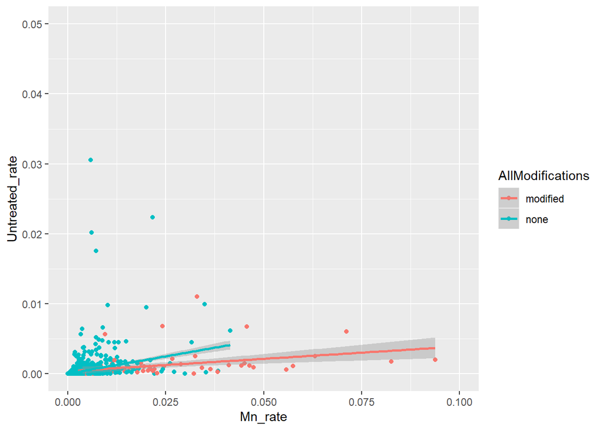

```r
plot <- ggplot(data = new.filtered, mapping = aes(x = Mn_rate, y = Untreated_rate,
                                                  col = AllModifications))

#For better viewing we have chosen the following window
plot + geom_point() + xlim(0, 0.10) + ylim(0, 0.05) + geom_smooth(method = "lm")
```

These histograms only consider the variable `Mn_rate` and compare the distribution of mutation rates of different sites between modified and un-modified sites. As we can see the modified sites show are much larger skew to the right.

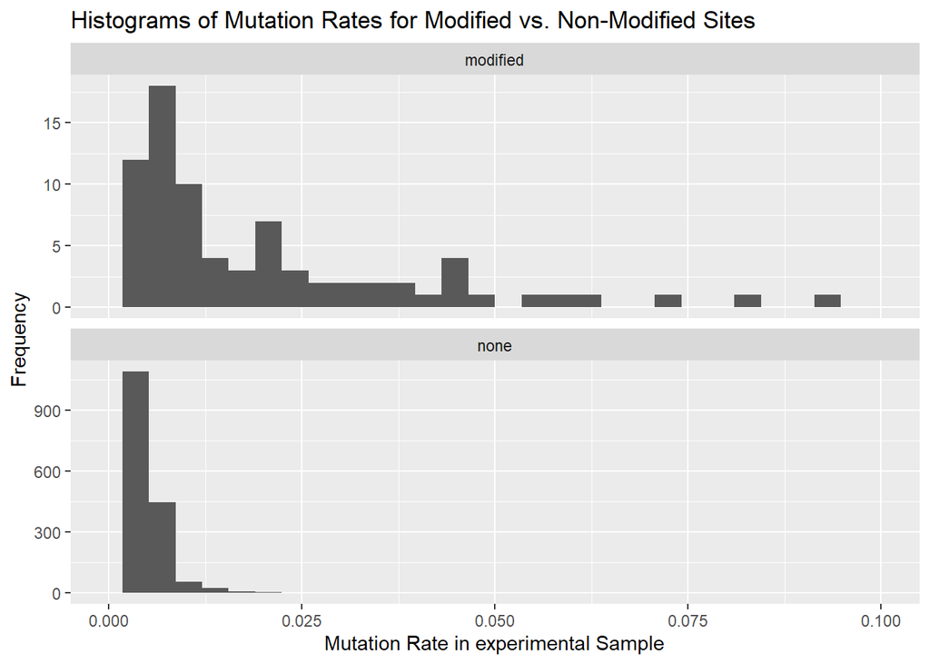

```r
new.filtered %>% ggplot(aes(x= Mn_rate)) + geom_histogram() +
  facet_wrap("AllModifications", ncol = 1, scales = "free_y") +
  xlim(0, 0.1) +
  labs(title = "Histograms of Mutation Rates for Modified vs. Non-Modified Sites",
       x = "Mutation Rate in experimental Sample", y = "Frequency")
```

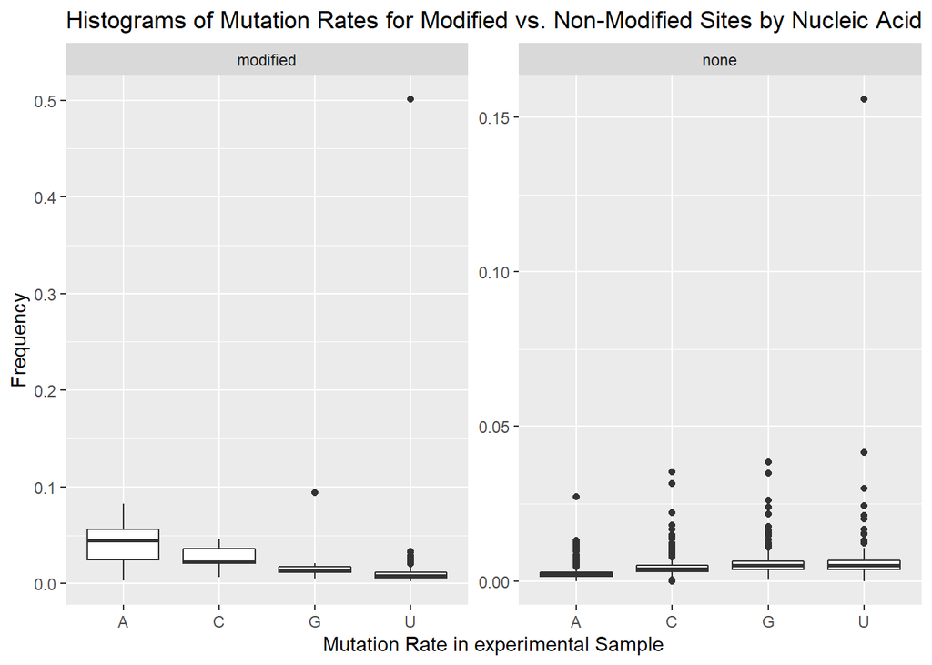

```r
new.filtered  %>% ggplot(aes(x= Sequence, y = Mn_rate)) + geom_boxplot() +
  facet_wrap("AllModifications", scale = "free_y") +
  #xlim(0, 0.1) +
  labs(title = "Histograms of Mutation Rates for Modified vs. Non-Modified Sites by Nucleic Acid",
       x = "Mutation Rate in experimental Sample", y = "Frequency")
```

### We really shouldn’t use ANOVA since the data is not normally distributed so here is Kruskal-wallis

```r
kruskal.test(Mn_rate ~ Sequence, data = new.filtered)
```

```
##
##  Kruskal-Wallis rank sum test
##
## data:  Mn_rate by Sequence
## Kruskal-Wallis chi-squared = 527.71, df = 3, p-value < 2.2e-16
```

```r
#Small p-value would indicate that the group means are different
```

### Not sure if we should include this

Notice that the distribution seems clearly non-normal (we can check this using qqplot, but the histogram does show a heavy right skew). We can use a nonparametric test to compare two means. This only tells us that there is in fact a difference in the mutation rates between the control and experimental samples. Notice there is also a (small) difference in mutation rates for *non-modified* sites as well.

```r
modified <- new.filtered %>% filter(AllModifications == "modified")

mean(modified$Mn_rate)
```

```
## [1] 0.02641872
```

```r
mean(modified$Untreated_rate)
```

```
## [1] 0.005365705
```

```r
wilcox.test(modified$Mn_rate, modified$Untreated_rate, alternative = "greater")
```

```
##
##  Wilcoxon rank sum test with continuity correction
##
## data:  modified$Mn_rate and modified$Untreated_rate
## W = 5905, p-value < 2.2e-16
## alternative hypothesis: true location shift is greater than 0
```

```r
unmodified <- new.filtered %>% filter(AllModifications == "none")


mean(unmodified$Mn_rate)
```

```
## [1] 0.004720355
```

```r
mean(unmodified$Untreated_rate)
```

```
## [1] 0.0005892922
```

```r
wilcox.test(unmodified$Mn_rate, unmodified$Untreated_rate, alternative = "greater")
```

```
##
##  Wilcoxon rank sum test with continuity correction
##
## data:  unmodified$Mn_rate and unmodified$Untreated_rate
## W = 3146862, p-value < 2.2e-16
## alternative hypothesis: true location shift is greater than 0
```

### delete this??

When looking at distribution of mutation rate for modified regions, we excluded outliers for greater visibility. However, we will include these points in our predictive model.

```r
modified_experimental_outliers <- boxplot(modified$Mn_rate, plot = FALSE)$out
modified_experimental_outliersrm <- modified[-which(modified$Mn_rate
                                                    %in% modified_experimental_outliers),]
dim(modified_experimental_outliersrm)
```

```
## [1] 73 10
```

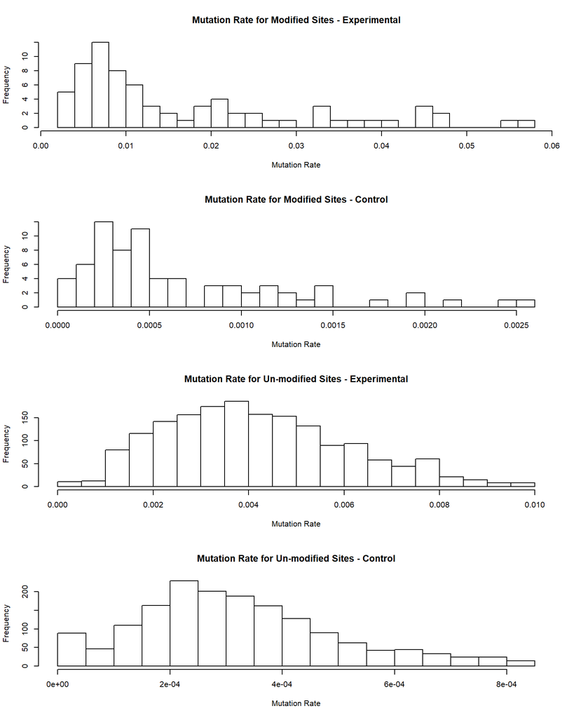

```r
#boxplot(modified_experimental_outliersrm$Mn_rate)


modified_control_outliers <- boxplot(modified$Untreated_rate, plot = FALSE)$out
modified_control_outliersrm <- modified[-which(modified$Untreated_rate
                                               %in% modified_control_outliers),]
#boxplot(modified_control_outliersrm$Untreated_rate)



#Looking at distribution of mutation rate for unmodified regions
unmodified_experimental_outliers <- boxplot(unmodified$Mn_rate, plot = FALSE)$out

unmodified_experimental_outliersrm <- unmodified[-which(unmodified$Mn_rate
                                                        %in% unmodified_experimental_outliers),]


#boxplot(unmodified_experimental_outliersrm$Mn_rate)


unmodified_control_outliers <- boxplot(unmodified$Untreated_rate, plot = FALSE)$out
unmodified_control_outliersrm <- unmodified[-which(unmodified$Untreated_rate
                                                   %in% unmodified_control_outliers),]

#boxplot(unmodified_control_outliersrm$Untreated_rate)


par(mfrow = c(4,1))
hist(modified_experimental_outliersrm$Mn_rate, nclass = 20,
     main = "Mutation Rate for Modified Sites - Experimental",, xlab = "Mutation Rate")
hist(modified_control_outliersrm$Untreated_rate, nclass = 20,
     main = "Mutation Rate for Modified Sites - Control",, xlab = "Mutation Rate")
hist(unmodified_experimental_outliersrm$Mn_rate, nclass = 20,
     main = "Mutation Rate for Un-modified Sites - Experimental",, xlab = "Mutation Rate")
hist(unmodified_control_outliersrm$Untreated_rate, nclass = 20,
     main = "Mutation Rate for Un-modified Sites - Control",, xlab = "Mutation Rate")
```

### Logistic Regression

To predict whether each site is modified or unmodified, we’ve created the dataset `logdata` which assigns value 1 as “modified” and 0 as "un-modified)

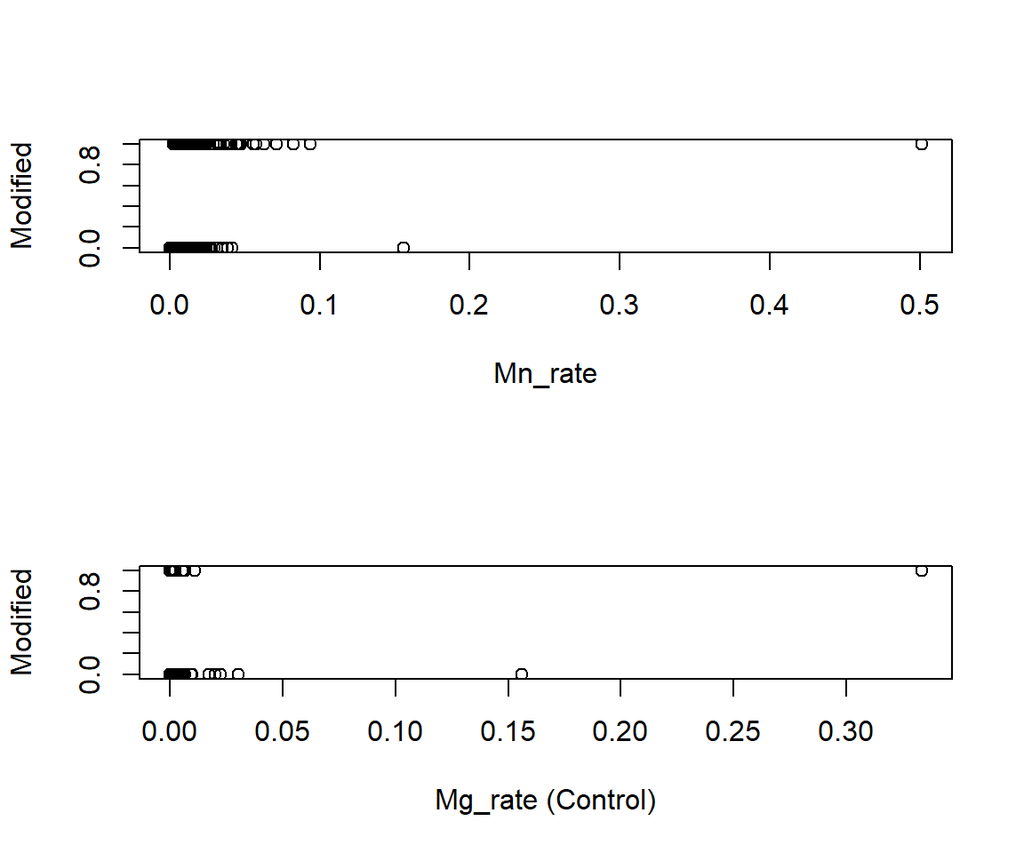

```r
logdata <- new.filtered %>% select(AllModifications, Mn_rate, Untreated_rate) %>%
  filter(Mn_rate < 0.8, Untreated_rate < 0.8) #filter(Mn_rate < 0.010022, Untreated_rate < 0.000855)

allmods <- gsub("none", 0, logdata$AllModifications)
allmods <- gsub("modified", 1, allmods)

logdata$AllModifications <- as.numeric(allmods)
#logdata

par(mfrow = c(2, 1))
plot(logdata$AllModifications ~ logdata$Mn_rate, ylab = "Modified", xlab = "Mn_rate")
plot(logdata$AllModifications ~ logdata$Untreated_rate,
     ylab = "Modified", xlab = "Mg_rate (Control)")
```

### Logistic Regression (based on class notes 4/8)

```r
hm1 <- glm(AllModifications ~ Mn_rate + Untreated_rate, family = binomial, logdata)

#hm2 <- glm(AllModifications ~ Mn_rate, family = binomial, logdata)

faraway::sumary(hm1)
```

```
##                  Estimate Std. Error z value  Pr(>|z|)
## (Intercept)      -4.69078    0.21684 -21.632 < 2.2e-16
## Mn_rate         212.42196   21.09683  10.069 < 2.2e-16
## Untreated_rate -211.92741   64.88906  -3.266  0.001091
##
## n = 1868 p = 3
## Deviance = 441.51275 Null Deviance = 648.13945 (Difference = 206.62670)
```

```r
#If the null model has one parameter and us true, we see the difference from a chi-square distribution is very large (the probability is very low)
1- pchisq(q = 59.92470, df = 2)
```

```
## [1] 9.714451e-14
```

The following curves show predictions for different values of the control mutation rate; as Untreated_rate increases, the probability that the point is *not* modified increases. However, we can see that this predictive model almost always predicts that the point is un-modified.

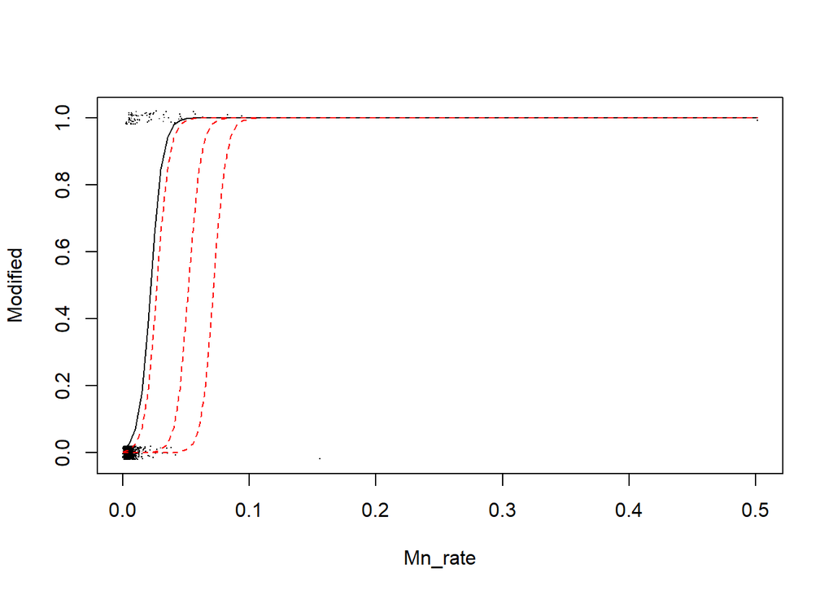

```r
beta <- coef(hm1)

plot(jitter(AllModifications,0.1) ~ jitter(Mn_rate),
     data=logdata, xlab="Mn_rate", ylab="Modified",pch=".")

curve(ilogit(beta[1] + beta[2]*x + beta[3]*0), add = TRUE)
curve(ilogit(beta[1] + beta[2]*x + beta[3]*0.005), add = TRUE, lty = 2, col = "red")
curve(ilogit(beta[1] + beta[2]*x + beta[3]*0.03), add = TRUE, lty = 2, col = "red")
curve(ilogit(beta[1] + beta[2]*x + beta[3]*0.05), add = TRUE, lty = 2, col = "red")
```

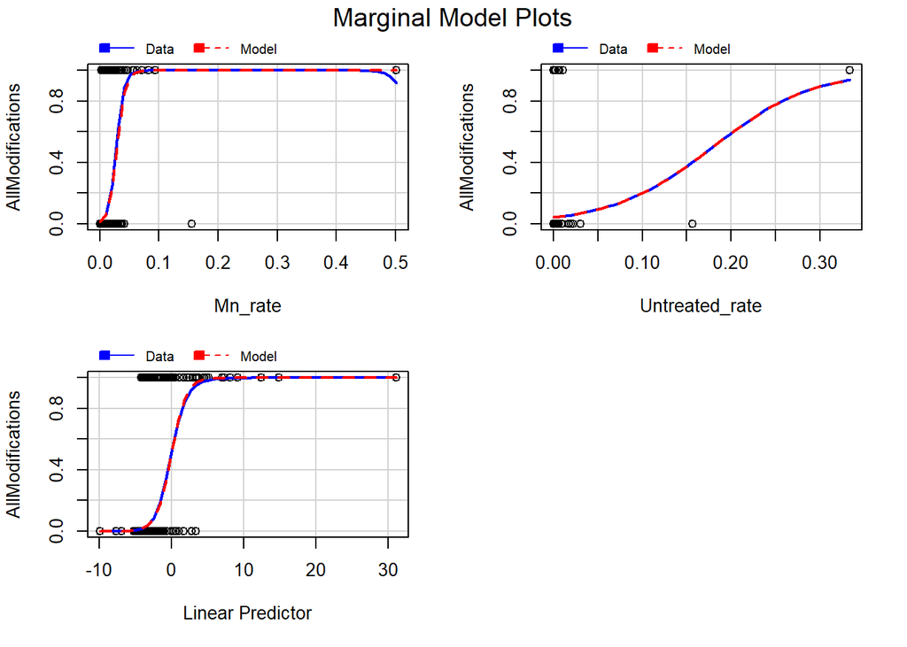

```r
car::marginalModelPlots(hm1)
```